# Exploration

The following script is best ran in a conda environment with dependencies python=3.11.5 and numpy=1.26.0 (conda activate Va_anal).

# 1 Patterns

First we assess how well we can estimate $V_a$ from simulated data where there is no burn-in phase. In these simulations, average effects are simply assigned to alleles at random with respect to their frequency. The main experimental set-up consists of 10 replicate populations each of 1000 individuals that evolve over 3 generations with the recombination rate during the experiment being $1.4\times10^{-6}$. Simulations were also ran where one of the parameter was changed: either 3 or 5 replicates, 100 or 500 individuals, 1 or 5 generations and a recombination rate of $1.4\times10^{-7}$ or $1.4\times10^{-8}$. We plot the estimates against the true values on the log-log scale, with the best linear fit for each set of simulation parameters plotted as a dashed line (the solid black line is the 1:1 line). In the legend we give the average proportional difference between the estimate and true value (a value of 1 would be unbiased, a value under one indicates downwardly bias) with a star indicating significant bias at a 5% significance threshold. The degree of bias may not be constant with respect to the true value of $V_a$. The deviation of the slope from one, on the log-log scale, we call the trend. When the trend is zero the proportional bias, if any, is constant with respect to $V_a$ (i.e. $\widehat{V_a}/V_a$ is constant). If the trend is positive it indicates that as $V_a$ increases $\widehat{V_a}/V_a$ becomes larger and if trend is negative it indicates that as $V_a$ increases $\widehat{V_a}/V_a$ gets smaller. A star indicates that the trend is significantly different from zero at a 5% significance threshold.

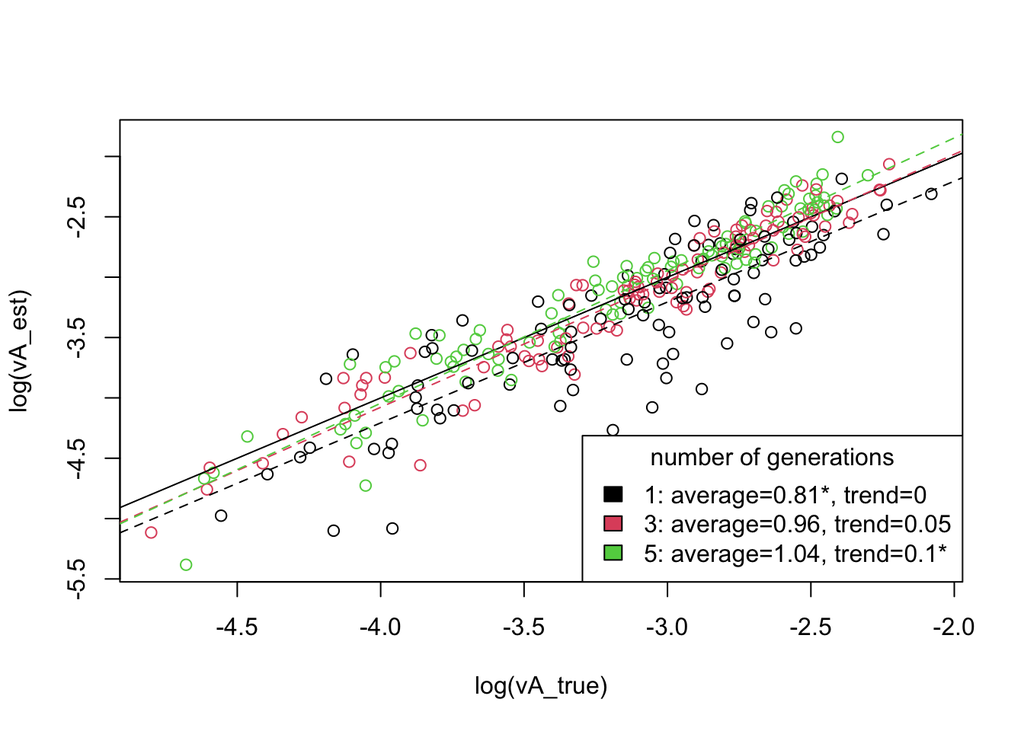

```r
dat<-read.csv("/Volumes/hadfield/Va_simulations/RESULTS_and_ANALYSES/No_burnin/Scale_0.033/Data_no_burnin.csv")


plot_res<-function(predictor=NULL){

  pred_names<-c("ngen_expt", "n_ind_exp", "n_cages", "r")
  real_names<-c("number of generations", "number of individuals", "number of replicates", "recombination rate")

  if(!predictor%in%pred_names){stop("predictor should be one of ngen_expt, n_ind_exp, n_cages or r")}

  delete<-rep(1, nrow(dat))

  if(predictor!="ngen_expt"){
    delete[dat$ngen_expt!=3]<-0
  }
  if(predictor!="n_ind_exp"){
    delete[dat$n_ind_exp!=1000]<-0
  }
  if(predictor!="n_cages"){
    delete[dat$n_cages!=10]<-0
  }
  if(predictor!="r"){
    delete[dat$r!=1.4e-06]<-0
  }
  delete[dat$vA_est>0.5]<-0


  dat.sub<-subset(dat, delete==1)
  colnames(dat.sub)[which(colnames(dat.sub)==predictor)]<-"p"
  model.sub1<-lm(log(vA_est)~as.factor(p)-1+offset(log(vA_true)), dat.sub)

  model.sub2<-lm(log(vA_est)~as.factor(p)-1+log(vA_true):as.factor(p)+offset(log(vA_true)), dat.sub)

 nlevels<-nlevels(as.factor(dat.sub$p))


 legend.names<-paste0(levels(as.factor(dat.sub$p)), ": average=", round(exp(coef(model.sub1)),2), c("", "*")[1+(coef(summary(model.sub1))[,4]<0.05)], ", trend=", round(coef(model.sub2)[nlevels+1:nlevels],2), c("", "*")[1+(coef(summary(model.sub2))[nlevels+1:nlevels,4]<0.05)])


  plot(log(vA_est)~log(vA_true), col=as.factor(p), data=dat.sub)
  abline(0,1)
  abline(coef(model.sub2)[1],1+coef(model.sub2)[4], lty=2, col=1)
  abline(coef(model.sub2)[2],1+coef(model.sub2)[5], lty=2, col=2)
  abline(coef(model.sub2)[3],1+coef(model.sub2)[6], lty=2, col=3)

  legend("bottomright", fill=1:3, legend=legend.names, title=real_names[match(predictor, pred_names)])

}

plot_res("ngen_expt")
```

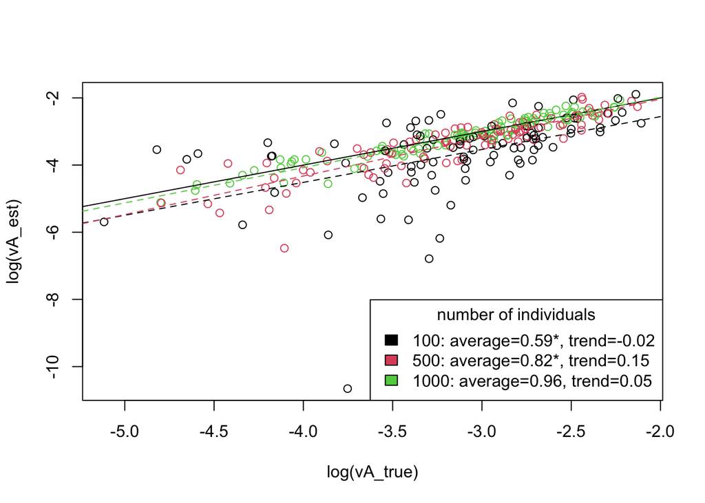

```r
plot_res("n_ind_exp")
```

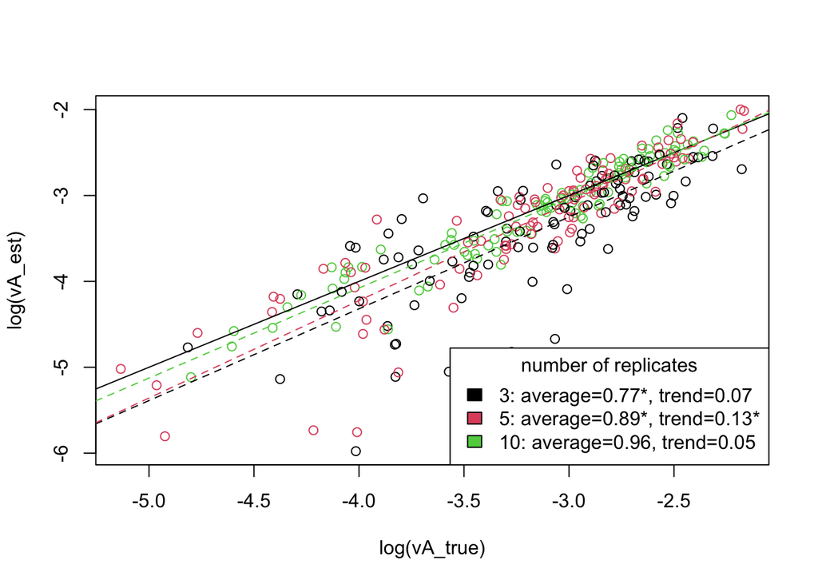

```r
plot_res("n_cages")
```

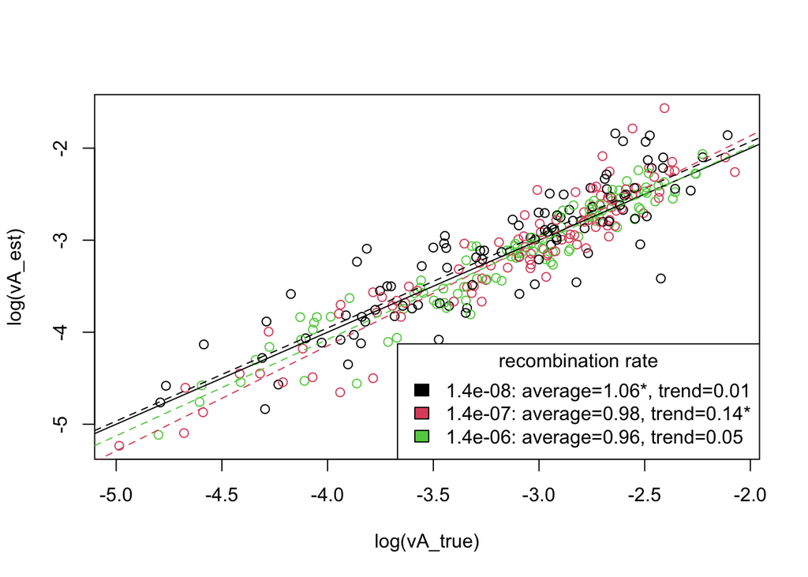

```r
plot_res("r")
```

The general pattern seems to be that there is downward bias as the amount of information decreases, either because the within-replicate variance increases because there is more drift (number of individuals per replicate is low) or the between replicate variance decreases because allele-frequencies change over a shorter amount of time (number of generations is low) or because the number of replicates is low. The proportional bias seems relatively constant, although there does seem to be some evidence that the downward bias is reduced as $V_a$ becomes larger (if bias is measured on the log (i.e. proportional) scale.

# 2 File Paths

```r
if(Sys.info()["nodename"]!="SCE-BIO-C06645"){message("WARNING: Command line arguments required!!!")}

### On AC3 ###

if(Sys.info()["nodename"]%in%c("bigfoot", "bigshot", "bigbird", "bigyin", "biggar", "bigwig", "c1", "c2", "c3", "c4", "c5", "c6")){

  base_path = "/ceph/users/marun/Va_simulations/1_Simulations"
  analysis_path = "/ceph/users/marun/Va_simulations/2_Analysis"
  file_storage_path = "/data/obbard/Va_simulations/analyses" # File storage path is the designated storage space on AC3 instead of the /home directory on qm

}

### On Vera ###

if(Sys.info()["nodename"]=="vera.bio.ed.ac.uk"){

  base_path = "/data/home/msamant/Manas/Va_simulations/Github/Va_simulations/1_Simulations"
  analysis_path = "/data/home/msamant/Manas/Va_simulations/Github/Va_simulations/2_Analysis"
  file_storage_path = base_path

}

### On Eddie ###

if(grepl("ecdf.ed.ac.uk", Sys.info()["nodename"])){
  base_path = "/home/msamant/Va_simulations/1_Simulations"
  analysis_path = "/home/msamant/Va_simulations/2_Analysis"
  file_storage_path = "/exports/eddie/scratch/msamant"
}

### On Manas's PC

if(Sys.info()["nodename"]=="SCE-BIO-C06645"){

  if(Sys.info()["sysname"]=="Linux"){   ## Local Wsl

    base_path = "/mnt/c/Users/msamant/Documents/GitHub/Va_simulations/1_Simulations"
    analysis_path = "/mnt/c/Users/msamant/Documents/GitHub/Va_simulations/2_Analysis"
    file_storage_path = base_path

  }else{                                ## Local windows

    base_path = "C:/Users/msamant/Documents/GitHub/Va_simulations/1_Simulations"
    analysis_path = "C:/Users/msamant/Documents/GitHub/Va_simulations/2_Analysis"
    file_storage_path = base_path
  }

}

### On Jarrod's PC ###

if(Sys.info()["nodename"]=="sce-bio-c04553"){
  base_path="~/Work/Va_simulations/1_Simulations"
  analysis_path = "~/Work/Va_simulations/2_Analysis"
  file_storage_path = base_path
  slim_path = "/Volumes/hadfield/Va_simulations/sim_files"
}else{
  slim_path = "/mnt/u/Datastore/CSCE/biology/groups/hadfield/Va_simulations/sim_files"
}


extract_genomes_path = file.path(analysis_path, "3_Extract_genomes.py")                                           ## Python script extracting mutations and genomes from the SLiM output file
extract_mut_path = file.path(analysis_path, "2_Extract_mutations.py")                                             ## Python script extracting mutations from the SliM output file

slim_output_path = file.path(slim_path, "SLiM_outputs")
# Path to SLiM output
slim_param_path = file.path(slim_path, "sim_params")
# Path to SLiM simulation parameters

temp_files_path = file.path(file_storage_path, "temp_files")
```

# 3 Load packages and functions

```r
if(Sys.info()["nodename"]=="bigyin"){stop("Bigyin cannot run asreml-r. Use a different code.")}

library(MCMCglmm)
library(asreml)
library(Matrix)
#library(rmutil)
library(pryr) ## For tracking memory usage using mem_used()
library(bigalgebra)
library(RhpcBLASctl)


#################################
#### Load Jarrod's functions ####
#################################

functions_only=TRUE ## Read only the functions

rmarkdown::render(file.path(analysis_path, "Vw.Rmd"), quiet=TRUE)

#rmarkdown::render("~/Desktop/tmp/Vw.Rmd", quiet=TRUE)

##############################
### Load Manas's functions ###
##############################

rmarkdown::render(file.path(analysis_path, "Vw_sim_functions.Rmd"), quiet=TRUE)
```

# 4 Get data

First enter the Set_ID of the simulations to be analysed

```r
Set_ID = "zero_test_bigyin_2024-10-09_16_53_28.860706_1.8969696969697e-07_1.4_1.4_1000_10_1_0_1"
```

and then extract data

```r
sim_data = extract_slim_data(Set_ID = Set_ID,
                             sim = 1,
                             slim_output_path = slim_output_path,
                             sim_param_path = slim_param_path,
                             extract_genomes_path = extract_genomes_path,
                             extract_mut_path = extract_mut_path,
                             mutations_path = temp_files_path,
                             c_matrix_path = temp_files_path,
                             randomise = TRUE,
                             verbose=FALSE)
```

# 5 Analyse data

```r
parents_info = analyse_parents(c_genome = sim_data$c_genome,
                               list_alpha = sim_data$list_alpha,
                               LDdelta=FALSE,
                               compute_svdL=TRUE,
                               SNPs = sim_data$SNPs,
                               RecombRate = sim_data$sim_params$r_expt,
                               HapLength = sim_data$sim_params$sequence_length,
                               AtleastOneRecomb=FALSE,
                               calc_nR=TRUE,
                               verbose=FALSE)
```

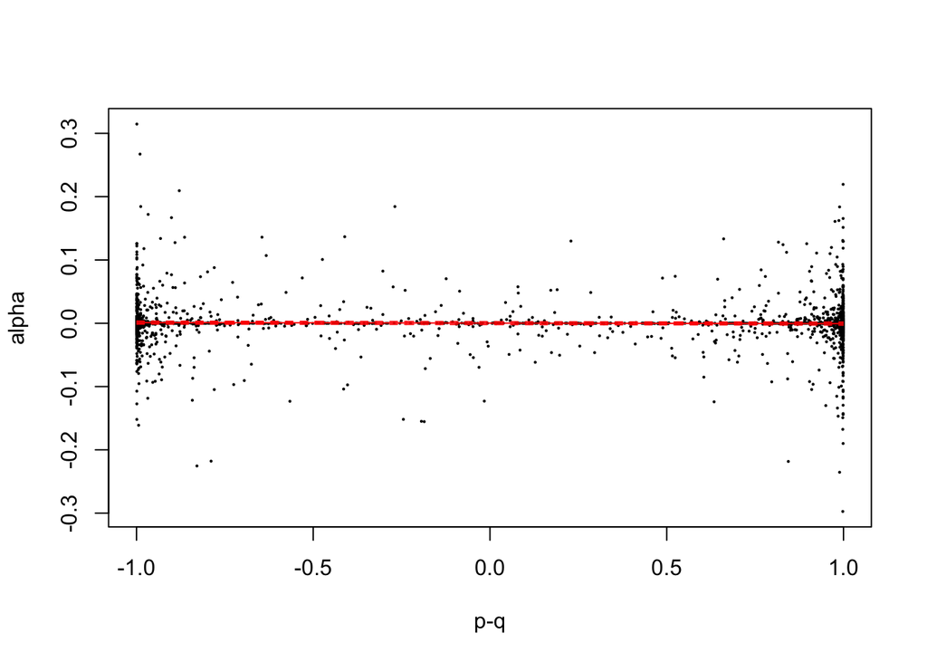

```r
plot_alpha_distribution(alpha = sim_data$list_alpha, p = sim_data$pbar0, parameters=parents_info$parameters, pch=16, cex=0.3)
```

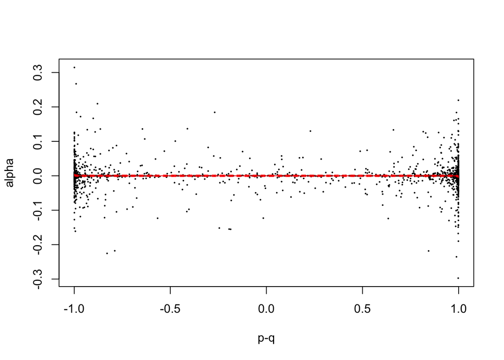

```r
 parameters.logit<-alpha_distribution(alpha=sim_data$list_alpha, p=sim_data$pbar0, logit=TRUE)

 plot_alpha_distribution(alpha = sim_data$list_alpha, p=sim_data$pbar0, parameters=parameters.logit, pch=16, cex=0.3)
```

# Model parameters

```r
# Analysis parameters
proj="BLoM" # projection type for allele frequencies: "LoM", "BLoM", "L" or "N"
LDdelta = FALSE
pa = 1
Vs = "LoNL" # "L" or "LoNL"
method="REML" # Can be "REML" or "MCMC"
randomise = TRUE # Should the reference allele be randomised for analysis?

# How is pdelta to be estimated?
# Can be "optim" (using the function optim()), or "fixed" or "manual"(estimated by manually scanning a range of pdelta values)

pdelta_method = "optim" # "optim" or "manual" or "fixed" or "no_analysis". If this is "no_analysis", the estimate of Vw is not calculated, but the rest of the code still runs.

if(pdelta_method=="fixed"){
  pdelta = 0 # Can be specified to any value
}

if(pdelta_method=="optim"){
  pdelta = NA # This triggers the use of optim() inside the function Vw_model()
}

if(pdelta_method=="manual"){

  nseq<-20 # The number of times pdelta is to be varied
  pdelta_l = -1 # Lower limit of pdelta
  pdelta_u = 1 # Upper limit of pdelta
  pdelta<-seq(pdelta_l, pdelta_u, length=nseq)

}

# How should bdelta[1] (intercept) and bdelta[2] (slope of (p-q)) be estimated

bdelta_method = "estimate"  # Can be "fixed" or "estimate"

if(bdelta_method=="estimate"){
  bdelta = c(NA, NA)
}else{
  bdelta = c(0, 0) # This only estimates the intercept while keeping the slope fixed at 0
}
```

```r
pointr::ptr("Ltilde", "parents_info$L")

m1<-Vw_model(c_genome = NULL,              # gametes genotypes
             nR = parents_info$nR,         # matrix of non-recombinant probabilities between loci
             pbar0 = sim_data$pbar0,       # vector of allele frequencies at time-point 1
             pbar1 = sim_data$pbar1,       # vector of allele frequencies at time-point 1
             ngen1= sim_data$ngen1,    # number of generations between parents and time-point 1
             pbar2 = sim_data$pbar2,       # vector of allele frequencies at time-point 2
             ngen2 = sim_data$ngen2,       # number of generations between parents and time-point 2
             nind = sim_data$sim_params$n_ind_exp,        # population size in each replicate
             proj=proj, # projection type for allele frequencies: "LoM", "BLoM", "L" or "N"
             LDdelta = LDdelta,
             pa = pa,
             pdelta = pdelta,
             bdelta = bdelta,
             Vs = Vs,
             method = method,
             L = parents_info$L,    # list with elements UL and DL
             Ltilde = Ltilde,    # list with elements UL and DL
             svdL = parents_info$svdL,    # list with elements UL and DL
             tol = sqrt(.Machine$double.eps),
             save_tprojp=TRUE,
             verbose=FALSE)
```

```
## ASReml Version 4.2 17/10/2024 14:36:32
##           LogLik        Sigma2     DF     wall
##  1     -11131.31      2.579307   9988   14:36:33  (  1 restrained)
##  2     -10431.91      2.673504   9988   14:36:33  (  1 restrained)
##  3     -10246.86      2.800191   9988   14:36:33
##  4     -10246.85      2.799897   9988   14:36:33
## ASReml Version 4.2 17/10/2024 14:36:39
##           LogLik        Sigma2     DF     wall
##  1     -11130.17      2.579409   9988   14:36:39  (  1 restrained)
##  2     -10431.46      2.673653   9988   14:36:40  (  1 restrained)
##  3     -10246.86      2.800310   9988   14:36:40
##  4     -10246.86      2.799911   9988   14:36:40
## ASReml Version 4.2 17/10/2024 14:36:46
##           LogLik        Sigma2     DF     wall
##  1     -11132.44      2.579204   9988   14:36:46  (  1 restrained)
```

[output cut: 226 more lines]

and then again with `Ltilde` taking into account the gametic phase disequilibrium

```r
m1_b<-Vw_model(c_genome = NULL,              # gametes genotypes
             nR = parents_info$nR,         # matrix of non-recombinant probabilities between loci
             pbar0 = sim_data$pbar0,       # vector of allele frequencies at time-point 1
             pbar1 = sim_data$pbar1,       # vector of allele frequencies at time-point 1
             ngen1= sim_data$ngen1,    # number of generations between parents and time-point 1
             pbar2 = sim_data$pbar2,       # vector of allele frequencies at time-point 2
             ngen2 = sim_data$ngen2,       # number of generations between parents and time-point 2
             nind = sim_data$sim_params$n_ind_exp,        # population size in each replicate
             proj=proj, # projection type for allele frequencies: "LoM", "BLoM", "L" or "N"
             LDdelta = LDdelta,
             pa = pa,
             pdelta = pdelta,
             bdelta = bdelta,
             Vs = Vs,
             method = method,
             L = parents_info$L,    # list with elements UL and DL
             Ltilde = parents_info$Ltilde,    # list with elements UL and DL
             svdL = parents_info$svdL,    # list with elements UL and DL
             tol = sqrt(.Machine$double.eps),
             save_tprojp=TRUE,
             verbose=FALSE)
```

```
## ASReml Version 4.2 17/10/2024 14:39:58
##           LogLik        Sigma2     DF     wall
##  1     -10947.44      2.485034   9988   14:39:58  (  1 restrained)
##  2     -10246.65      2.566690   9988   14:39:58  (  1 restrained)
##  3     -10072.10      2.698320   9988   14:39:58
##  4     -10070.82      2.687178   9988   14:39:59
##  5     -10070.79      2.685479   9988   14:39:59
##  6     -10070.79      2.685413   9988   14:39:59
## ASReml Version 4.2 17/10/2024 14:40:05
##           LogLik        Sigma2     DF     wall
##  1     -10946.30      2.485114   9988   14:40:05  (  1 restrained)
##  2     -10246.20      2.566831   9988   14:40:05  (  1 restrained)
##  3     -10072.14      2.698457   9988   14:40:06
##  4     -10070.83      2.687223   9988   14:40:06
##  5     -10070.80      2.685496   9988   14:40:06
```

[output cut: 242 more lines]

# 6 Extract estimates

```r
vA_est = m1$Vw_est
pdelta_est = m1$pdelta
pdelta_var_est = m1$pdelta_var
bdelta_intercept_est = m1$bdelta[1]
bdelta_slope_est = m1$bdelta[2]
bdelta_var_est = paste(m1$bdelta_var[1,1], m1$bdelta_var[2,2], m1$bdelta_var[1,2], sep = "_")
sigma2delta_est = summary(m1$model)$varcomp[1,1]
```

Look at alpha-estimates under projected allele frequencies

```r
 parameters.linear<-alpha_distribution(alpha=sim_data$list_alpha, p=sim_data$pbar0, tprojp=m1$tprojp, save_model=TRUE)
 parameters.logit<-alpha_distribution(alpha=sim_data$list_alpha, p=sim_data$pbar0, tprojp=m1$tprojp, logit=TRUE, save_model=TRUE)
```

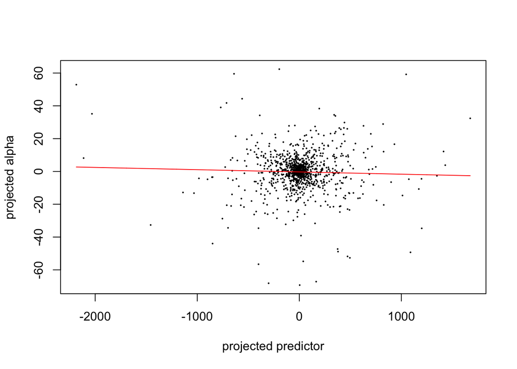

```r
plot_alpha_distribution(alpha = sim_data$list_alpha, p=sim_data$pbar0, tprojp=m1$tproj, parameters=parameters.linear, pch=16, cex=0.3)
```

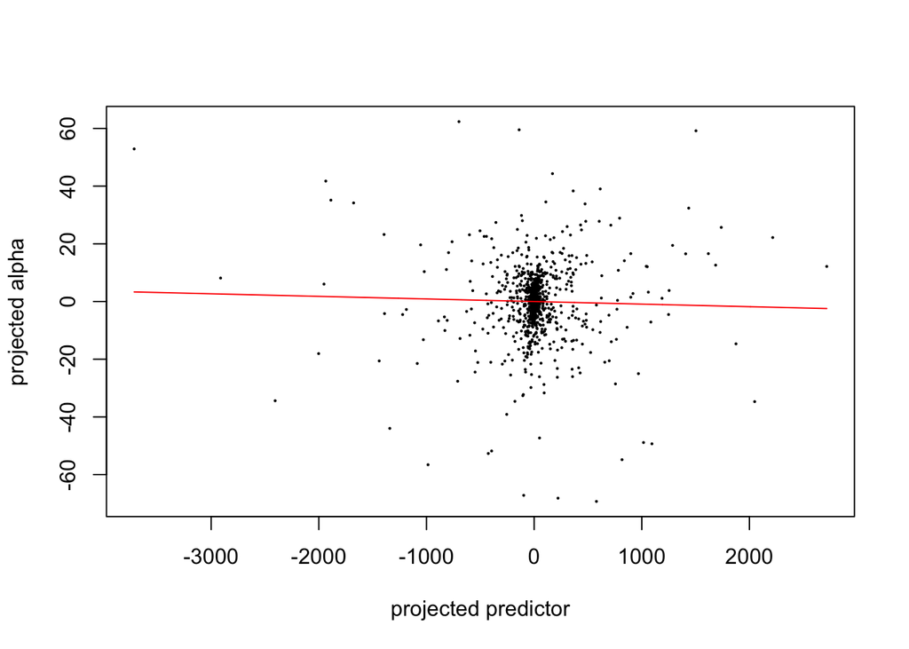

```r
plot_alpha_distribution(alpha = sim_data$list_alpha, p=sim_data$pbar0, tprojp=m1$tproj, parameters=parameters.logit, pch=16, cex=0.3)
```

Compare to Buffalo and Coop’s method

```r
est_Va_bc(sim_data$pbar1, sim_data$pbar2, parents_info$L, parents_info$nR, nrep=10)
```

[output not shown]